# Chapter 16 Notes

**Chapter 16 Notes - Solubility and Complex Ion Equilibria**

**Solubility product constant / solubility product**: An equilibrium constant for the dissolving of soluble solids. K<sub>sp</sub> = [A<sup>+</sup>]<sup>a</sup>[B<sup>-</sup>]<sup>b</sup> where a and b are the relative concentrations (coefficients) of the cation and anion. Written according to the law of mass action.

Solubility is an equilibrium position (can be multiple at a given temp); solubility product (K<sub>sp</sub>) is an equilibrium constant (only one per reaction at a given temp).

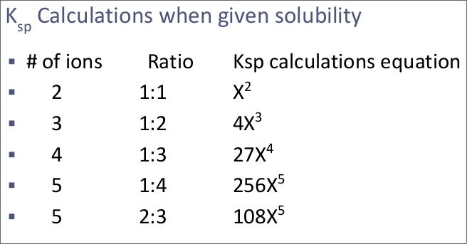

(x is solubility)

We must be careful using K<sub>sp</sub> values to predict the *relative* solubility of a group of salts. If the salts produce the same number of ions, then the largest K<sub>sp</sub> will be the most soluble. However if the salts produce different numbers of ions, then the K<sub>sp</sub> values *cannot* be compared directly to determine the order of solubility.

For an example of a salt dissolving in water that contains an ion common in the salt, take solid silver chromate (Ag<sub>2</sub>CrO<sub>4</sub>) in a 0.1M solution of AgNO<sub>3</sub> . Since NO<sub>3</sub><sup>-</sup> is not found in the salt, it can be ignored. Relevant initial concentrations:

[Ag<sup>+</sup>]<sub>0</sub> = 0.1M, [CrO<sub>4</sub><sup>2-</sup>]<sub>0</sub> = 0 . The system comes to equilibrium according to the reaction

Ag<sub>2</sub>CrO<sub>4</sub>(s) <-> 2Ag<sup>+</sup>(aq) + CrO<sub>4</sub><sup>2-</sup>(aq) , and K<sub>sp</sub> = [Ag<sup>+</sup>]<sup>2</sup>[CrO<sub>4</sub><sup>2-</sup>] = 9*10^-12 is given.

Apply a variable x denoting change to equilibrium:

[Ag<sup>+</sup>] = [Ag<sup>+</sup>]<sub>0</sub> + change = 0.1 + 2x

[CrO<sub>4</sub><sup>2-</sup>] = [CrO<sub>4</sub><sup>2-</sup>]<sub>0</sub> + change = 0 + x

Using the K<sub>sp</sub> formula, 9*10^-12 = (0.1 + 2x)<sup>2</sup>(x) . This looks complicated, but since x is expected to be way smaller than 0.1 (K<sub>sp</sub> is small => eq.pt. Is far to the left => change is small), we can simplify to (0.1)<sup>2</sup>(x). Thus, x = 9*10^-12 / 0.01 = 9*10^-10M

Plugging X in, we get

[Ag<sup>+</sup>] = 0.1 + 2x = 0.1 M

[CrO<sub>4</sub><sup>2-</sup>] = 0 + x = 9*10^-10 M

This is much less than its solubility in pure water, which is an example of the common ion effect. The solubility of a solid is lowered if the solution already contains ions common to the solid.

The pH of a solution can greatly affect a salt’s solubility. IF the salt’s anion is from a *weak* acid (*strong* base), its solubility will be greater in acidic solutions, as the H<sup>+</sup> ions will react with the strong base, pushing the equilibrium point to the right (common ion effect). For example, the PO<sub>4</sub><sup>3-</sup> in Ag<sub>3</sub>PO<sub>4</sub> would react with H<sup>+</sup> ions in an acidic solution to form HPO<sub>3</sub><sup>2-</sup>, reducing the concentration of PO<sub>4</sub><sup>3-</sup> and thus pushing the eq.pt. to the right.

**Ion product**: defined just like the expression for K<sub>sp</sub> for a given solid except that *initial concentrations* are used instead of equilibrium concentrations. I.e. for CaF<sub>2</sub>,

Q = [Ca<sup>2+</sup>]<sub>0</sub>[F<sub>2</sub><sup>-</sup>]<sub>0</sub>

The ion product is used to predict whether a solid precipitate will form when two solutions are mixed, as follows:

- If Q > K<sub>sp</sub> , precipitation occurs until the point where the concentrations are reduced enough to satisfy K<sub>sp</sub> .
- If Q < K<sub>sp</sub> , no precipitation occurs.

Sometimes we want to know not just whether a precipitate will form but also the equilibrium concentrations after it has occurred. Taking Pb(NO<sub>3</sub>)<sub>2</sub> + NaI as an example which makes PbI<sub>2</sub> (Q > K<sub>sp</sub> => precipitation will occur), since K<sub>sp</sub> is quite small, most of the ions when mixed will exist as PbI<sub>2</sub> . I.e. the reaction Pb<sup>2+</sup> + 2I<sup>-</sup> -> PbI<sub>2</sub>(s) goes nearly to completion.

Note: If, when two solutions are mixed, their reaction goes virtually to completion, it is essential to do the stoichiometry calculations before considering the equilibrium calculations. So in the case of PbI<sub>2</sub> , we will first let the precipitation go 100% to completion, and then adjust it back to meet equilibrium.

Pb<sup>2+</sup> + 2I<sup>-</sup> -> PbI<sub>2</sub> (doesn't matter here)

Before Rxn 5 mmol 20 mmol

After Rxn 0 mmol 20-2(5)=10 mmol I<sup>-</sup>

Then,

[Pb<sup>2+</sup>]<sub>0</sub> = 0 , [I<sup>-</sup>]<sub>0</sub> = 10 mmol / 300ml = 3.33*10^-2 M

Now the reaction is, PbI<sub>2</sub>(s) <-> Pb<sup>2+</sup>(aq) + 2I<sup>-</sup>(aq) ; i.e., how much PbI<sub>2</sub> will dissolve in a 3.33*10^-2 M solution of NaI?

Plugging everything into K<sub>sp</sub> = 1.4 * 10^-8 (given) = [Pb<sup>2+</sup>][I<sup>-</sup>]<sup>2</sup> = (x)(3.33e-2+2x)^2

Simplifying, 1.4e-8 = x(3.33e-2)^2, x = 1.3*10^-5

[Pb<sup>2+</sup>]<sub>0</sub> = x = 1.3*10^-5 , [I<sup>-</sup>]<sub>0</sub> = 3.33*10^-2 + 2x = 3.33*10^-2

**Complex ion**: a charged species consisting of a metal ion surrounded by ligands.

**Ligand**: a Lewis base; a molecule or ion having a lone electron pair that can be donated to an empty orbital on the metal ion to form a covalent bond (common ligands: H<sub>2</sub>O, NH<sub>3</sub>, Cl<sup>-</sup>, CN<sup>-</sup>)

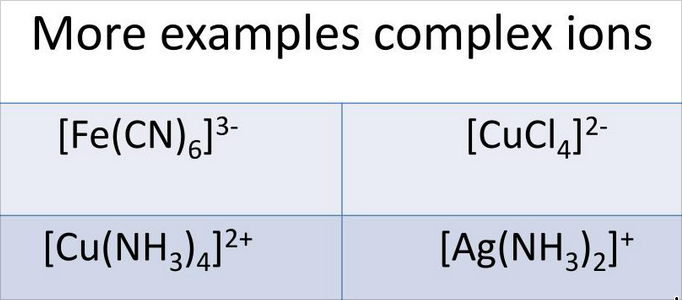

The number of ligands attached to a metal ion is called the *coordination number*. The most common coordination numbers are 6, 4, and 2 (here’s a 6 example: Co(H<sub>2</sub>O)<sub>6</sub><sup>2+</sup>)

In stepwise reactions, the overall equilibrium constant is the sum of the equilibrium expressions for each step’s reaction.